# 準備

```r
# データの加工用ライブラリ
library(stringr)
library(dplyr)

# ラスターの加工用ライブラリ
library(raster)
library(sf)
library(lattice)

# プロット用のライブラリ
library(ggplot2)

# 種分布モデリング (MaxEnt) 実行用ライブラリ
## 実行にはパスを通すなどの処理が必要になる。
library(SDMtune)
library(rJava)
library(dismo)

# 重回帰分析で用いるライブラリ
library(car)
```

## データ処理関数の定義

```r
mesh2get <- function(x, y){
    p <- (y * 60) %/% 40
    a <- (y * 60) %% 40
    u <- (x - 100) %/% 1
    f <- (x - 100) %% 1
    q <- a %/% 5
    b <- a %% 5
    v <- (f * 60) %/% 7.5
    g <- (f * 60) %% 7.5

    p * 10000 + u * 100 + q * 10 + v * 1
}

latget <- function(mesh2){
    trunc(mesh2 / 10000) * 2/3 + trunc(mesh2 %% 100 / 10) * 2/3 / 8
}
longet <- function(mesh2){
    100 + trunc((mesh2 - trunc(mesh2 / 10000)*10000) / 100) + mesh2 %% 10 / 8
}
```

## 環境データの読み込み&確認

```r
env_data <- read.csv("C:/Users/ikari/Documents/laboratory/projects/202205_data_portal/data.website/assets/data/dummy_data/dummy_environment_grid10km.csv")
```

```r
head(env_data)
colnames(env_data)
```

A data.frame: 6 × 24

|  | mesh2 <int> | x <dbl> | y <dbl> | elevation <dbl> | land.area <int> | bio_1 <dbl> | bio_2 <dbl> | bio_3 <dbl> | bio_4 <dbl> | bio_5 <dbl> | ... | bio_10 <dbl> | bio_11 <dbl> | bio_12 <dbl> | bio_13 <dbl> | bio_14 <dbl> | bio_15 <dbl> | bio_16 <dbl> | bio_17 <dbl> | bio_18 <dbl> | bio_19 <dbl> |
| --- | --- | --- | --- | --- | --- | --- | --- | --- | --- | --- | --- | --- | --- | --- | --- | --- | --- | --- | --- | --- | --- |
| 1 | 362257 | 122.9375 | 24.45833 | 39.300000 | 17931194 | 235.2400 | 43.81667 | 29.21916 | 3789.108 | 311.6800 | ... | 277.1100 | 191.3300 | 2316.696 | 238.4080 | 131.6240 | 18.63271 | 926.1640 | 612.6080 | 754.5040 | 695.4280 |
| 2 | 362306 | 123.8125 | 24.04167 | 20.526316 | 12594416 | 240.4211 | 46.21053 | 30.68839 | 3674.462 | 318.6316 | ... | 280.9079 | 197.7237 | 1805.284 | 197.5895 | 121.7526 | 18.14351 | 729.5316 | 495.2211 | 660.7474 | 495.2211 |
| 3 | 362324 | 123.5625 | 24.20833 | 25.150000 | 199129 | 233.0000 | 52.08333 | 32.55208 | 3853.412 | 314.0000 | ... | 275.2500 | 188.0000 | 2112.500 | 251.3000 | 129.1000 | 20.79034 | 873.4000 | 560.0000 | 756.9000 | 592.9000 |
| 4 | 362327 | 123.9375 | 24.20833 | 5.546154 | 4801966 | 236.6923 | 53.56410 | 32.59977 | 3902.169 | 319.6923 | ... | 279.3846 | 191.1538 | 1922.669 | 226.3846 | 122.0385 | 20.68535 | 794.8538 | 517.4462 | 710.3231 | 519.3846 |
| 5 | 362335 | 123.6875 | 24.29167 | 106.877778 | 35299545 | 229.6222 | 53.33519 | 33.05452 | 3891.448 | 311.6667 | ... | 272.1500 | 184.1500 | 2352.660 | 286.8911 | 137.3067 | 21.89230 | 983.0067 | 630.0867 | 879.7000 | 660.5111 |
| 6 | 362336 | 123.8125 | 24.29167 | 168.780488 | 88173854 | 225.5976 | 53.73069 | 32.97588 | 3961.892 | 308.5122 | ... | 268.8262 | 179.2683 | 2799.691 | 359.2988 | 142.6341 | 28.09453 | 1257.6402 | 703.9976 | 1079.4439 | 730.3488 |

1. 'mesh2'

2. 'x'

3. 'y'

4. 'elevation'

5. 'land.area'

6. 'bio_1'

7. 'bio_2'

8. 'bio_3'

9. 'bio_4'

10. 'bio_5'

11. 'bio_6'

12. 'bio_7'

13. 'bio_8'

14. 'bio_9'

15. 'bio_10'

16. 'bio_11'

17. 'bio_12'

18. 'bio_13'

19. 'bio_14'

20. 'bio_15'

21. 'bio_16'

22. 'bio_17'

23. 'bio_18'

24. 'bio_19'

bio_1 … BIO1 = 年平均気温  
bio_2 … BIO2 = 気温の日較差  
bio_3 … BIO3 = 等温性  
bio_4 … BIO4 = 気温の季節性  
bio_5 … BIO5 = 最暖月最高気温  
bio_6 … BIO6 = 最寒月最高気温  
bio_7 … BIO7 = 気温の年較差  
bio_8 … BIO8 = 湿潤な四半期の平均気温  
bio_9 … BIO9 = 乾燥した四半期の平均気温  
bio_10 … BIO10 = 最も暖かい四半期の平均気温  
bio_11 … BIO11 = 最も寒冷な四半期の平均気温  
bio_12 … BIO12 = 年降水量  
bio_13 … BIO13 = 最も湿潤な月の降水量  
bio_14 … BIO14 = 最も乾燥した月の降水量  
bio_15 … BIO15 = 降水量の季節性  
bio_16 … BIO16 = 湿潤な四半期の降水量  
bio_17 … BIO17 = 乾燥した四半期の降水量  
bio_18 … BIO18 = 最も暖かい四半期の降水量  
bio_19 … BIO19 = 最も寒冷な四半期の降水量

### ラスター化

```r
## 環境データのラスター化
for (ii in 4:ncol(env_data)){
    assign(colnames(env_data)[ii], rasterFromXYZ(env_data[,c(2,3,ii)]))
}

for(ii in 4:ncol(env_data)){
    if(ii == 4){
                xy2 = get(colnames(env_data)[ii])
            } else {
                xy2 = stack(xy2,get(colnames(env_data)[ii]))
    }
}

crs(xy2) = "+proj=longlat +datum=WGS84 +no_defs +ellps=WGS84 +towgs84=0,0,0"

# 21の環境変数がラスターとして格納されている
nlayers(xy2)
```

21

## 生物の在データの読み込み

```r
OCC_DATA <- read.csv("C:/Users/ikari/Documents/laboratory/projects/202205_data_portal/data.website/assets/data/dummy_data/dummy_species_grid10km.csv")
OCC_DATA$mesh2 <- mesh2get(OCC_DATA$longitude, OCC_DATA$latitude)
OCC_DATA$count <- 1
```

```r
OCC_DATA <- OCC_DATA[OCC_DATA$Category=="nat.",]
OCC_DATA_use <- OCC_DATA[, c("species", "longitude", "latitude", "mesh2")]
sp_list <- unique(OCC_DATA$species)
sp_list
```

1. 'sp1'

2. 'sp2'

3. 'sp3'

4. 'sp4'

5. 'sp5'

6. 'sp6'

7. 'sp7'

8. 'sp8'

9. 'sp9'

10. 'sp10'

11. 'sp11'

12. 'sp12'

13. 'sp13'

14. 'sp14'

15. 'sp15'

16. 'sp16'

17. 'sp17'

18. 'sp18'

19. 'sp19'

20. 'sp20'

21. 'sp21'

22. 'sp22'

23. 'sp23'

24. 'sp24'

25. 'sp25'

26. 'sp26'

27. 'sp27'

28. 'sp28'

29. 'sp29'

30. 'sp30'

31. 'sp31'

32. 'sp32'

33. 'sp33'

34. 'sp34'

35. 'sp35'

36. 'sp36'

37. 'sp37'

38. 'sp38'

39. 'sp39'

40. 'sp40'

41. 'sp41'

42. 'sp42'

43. 'sp43'

44. 'sp44'

45. 'sp45'

46. 'sp46'

47. 'sp47'

48. 'sp48'

49. 'sp49'

50. 'sp50'

51. 'sp51'

52. 'sp52'

53. 'sp53'

54. 'sp54'

55. 'sp55'

56. 'sp56'

57. 'sp57'

58. 'sp58'

59. 'sp59'

60. 'sp60'

61. 'sp61'

62. 'sp62'

63. 'sp63'

64. 'sp64'

65. 'sp65'

66. 'sp66'

67. 'sp67'

68. 'sp68'

69. 'sp69'

70. 'sp70'

71. 'sp71'

72. 'sp72'

73. 'sp73'

74. 'sp74'

75. 'sp75'

76. 'sp76'

77. 'sp77'

78. 'sp78'

79. 'sp79'

80. 'sp80'

81. 'sp81'

82. 'sp82'

83. 'sp83'

84. 'sp84'

85. 'sp85'

86. 'sp86'

87. 'sp87'

88. 'sp88'

89. 'sp89'

90. 'sp90'

91. 'sp91'

92. 'sp92'

93. 'sp93'

94. 'sp94'

95. 'sp95'

96. 'sp96'

97. 'sp97'

98. 'sp98'

99. 'sp99'

100. 'sp100'

101. 'sp101'

102. 'sp102'

103. 'sp103'

104. 'sp104'

105. 'sp105'

106. 'sp106'

107. 'sp107'

108. 'sp108'

109. 'sp109'

110. 'sp110'

111. 'sp111'

112. 'sp112'

113. 'sp113'

114. 'sp114'

115. 'sp115'

116. 'sp116'

117. 'sp117'

118. 'sp118'

119. 'sp119'

120. 'sp120'

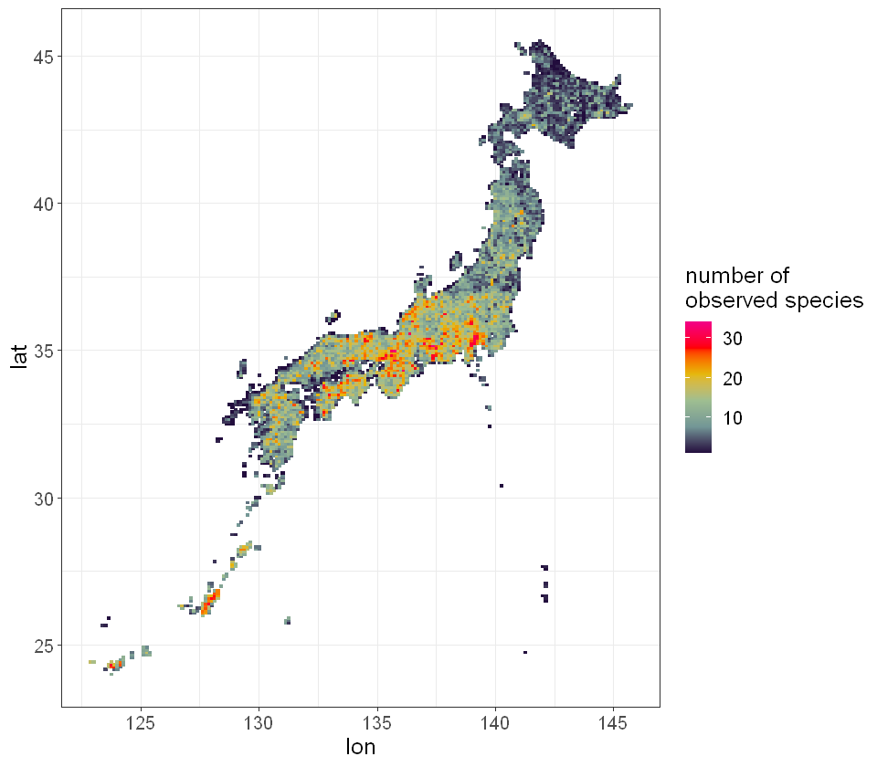

```r
records <- aggregate(list("obs_n"=OCC_DATA$count), list("mesh2"=OCC_DATA$mesh2), sum)
records$lat <- latget(records$mesh2)
records$lon <- longet(records$mesh2)

pal<- c("#220d3d", "#729696", "#9EBE91", "#E4B80E", "#ff0000","#f20085")

options(repr.plot.width=8, repr.plot.height=7)
ggplot() + geom_tile(data=records, aes(x=lon, y=lat, color=obs_n, fill=obs_n)) +
theme_bw()+ theme(text = element_text(size = 15))+
scale_fill_gradientn(colors = pal, na.value = NA, name = "number of \nobserved species") +
scale_color_gradientn(colors = pal, na.value = NA, name = "number of \nobserved species")
```

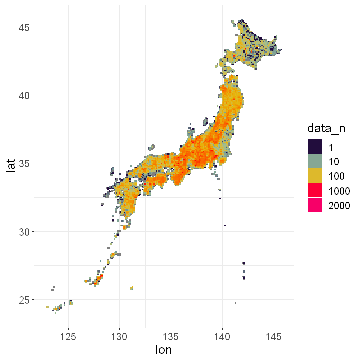

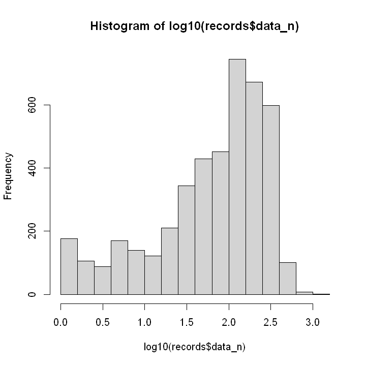

```r
records <- aggregate(list("data_n"=rowSums(OCC_DATA[, c("pre.1949", "X1950.1959","X1960.1969", "X1970.1979", "X1980.1989", "X1990.1999", "X2000.2009", "X2010.")], na.rm = T)),
                     list("mesh2"=OCC_DATA$mesh2), sum)

records$lat <- latget(records$mesh2)
records$lon <- longet(records$mesh2)

options(repr.plot.width=6, repr.plot.height=6)
ggplot() + geom_tile(data=records, aes(x=lon, y=lat, color=data_n, fill=data_n)) +
theme_bw()+ theme(text = element_text(size = 15))+
scale_fill_gradientn(colors = pal,
                          breaks=c(1, 10, 100, 1000, 2000),
                          limits=c(1, 3000), guide = "legend",  trans = "log") +
scale_color_gradientn(colors = pal,
                          breaks=c(1, 10, 100, 1000, 2000),
                          limits=c(1, 3000), guide = "legend",  trans = "log")

hist(log10(records$data_n))
```

```
Warning message:
"Removed 269 rows containing non-finite values (stat_smooth)."
```

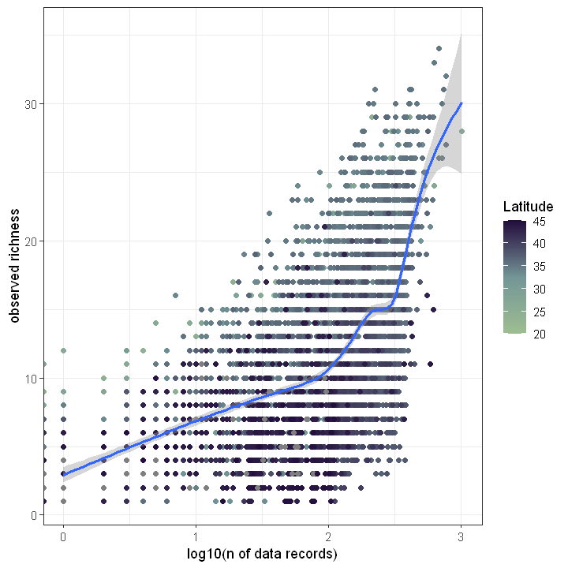

```r
latpal<- c("#9EBE91", "#729696", "#220d3d")

records <- aggregate(list("obs_n"=OCC_DATA$count, "data_n"=rowSums(OCC_DATA[, c("pre.1949", "X1950.1959","X1960.1969", "X1970.1979", "X1980.1989", "X1990.1999", "X2000.2009", "X2010.")], na.rm = T)),
                     list("mesh2"=OCC_DATA$mesh2), sum)
records$lat <- latget(records$mesh2)
records$lon <- longet(records$mesh2)

options(repr.plot.width=6, repr.plot.height=6)
ggplot(data=records, aes(y=obs_n, x=log10(data_n), color=lat)) + geom_point() + stat_smooth()+
scale_color_gradientn(colors = latpal,
                          breaks=seq(20,45, by=5),
                          limits=c(20, 45), name="Latitude")+xlab("log10(n of data records)")+ylab("observed richness") + theme_bw()
```

↑データレコード数と観測種数には強い関連がある 。一般に、よくある現象  
(ggplotのデフォルトloess曲線を合わせて図示)

# 種分布モデリング

```r
maxent_repeat <- function(data_use, sp_list){
    layers <- 0
    sdm_stacker <- NA
    thss <- NA
    sp.label <- NA
    for (ii in 1:length(sp_list)){

        taxon <- sp_list[ii]

        data_temp <- subset(data_use, data_use$species==taxon)
        data_temp <- data_temp[!duplicated(data_temp$mesh2), c(2,3)]

        if (nrow(data_temp) < 6){
            print(c("data too few", taxon))
            next
        }

        colnames(data_temp) <- c("x", "y")
        bg_temp <-sample_n(tbl = env_data[, c(2,3)], size = 1000)
        colnames(bg_temp) <- c("x", "y")
        data <- prepareSWD(species = taxon, p = data_temp, a = bg_temp,env = xy2)

        model <- train(method = "Maxent", data = data, iter=1000)

        # 分布モデルの学習
        pred <- predict(model, data = data, type = "cloglog")

        # 分布予測
        map <- predict(model, data = xy2, type = "cloglog")
        names(map) <- taxon
        ths <- thresholds(model, type = "cloglog")[3,2]

        cont_map <- map
        names(cont_map) <- taxon

        map[map[] < ths] <- 0
        map[map[] >= ths] <- 1

        if(layers==0){
                shm_stacker  = cont_map
                sdm_stacker  = map
                thss <- data.frame("taxon"=taxon, "threshold"=ths)
            }else{
                shm_stacker  = stack(shm_stacker, cont_map)
                sdm_stacker  = stack(sdm_stacker, map)
                thss <- rbind(thss, data.frame("taxon"=taxon, "threshold"=ths))
        }
        layers <- layers + 1
    }
    return(list("sdm"=sdm_stacker, "hsm"=shm_stacker, "ths"=thss))
}
```

```r
SDM_stack <- maxent_repeat(OCC_DATA_use, sp_list)
saveRDS(SDM_stack, "../output/dummy_10km_envonly.rds")
```

```r
SDM_stack <- readRDS("../output/dummy_10km_envonly.rds")
```

# 種多様性解析

```r
tr <- calc(readRDS(paste("C:/Users/ikari/Documents/laboratory/projects/202210_seminar/output/dummy_10km_envonly.rds", sep=""))$sdm, sum)
td <- as.data.frame(rasterToPoints(tr))
colnames(td) <- c("x", "y", "dummytaxon")
```

```r
tdata_t <-env_data
```

## 種数マップの図示

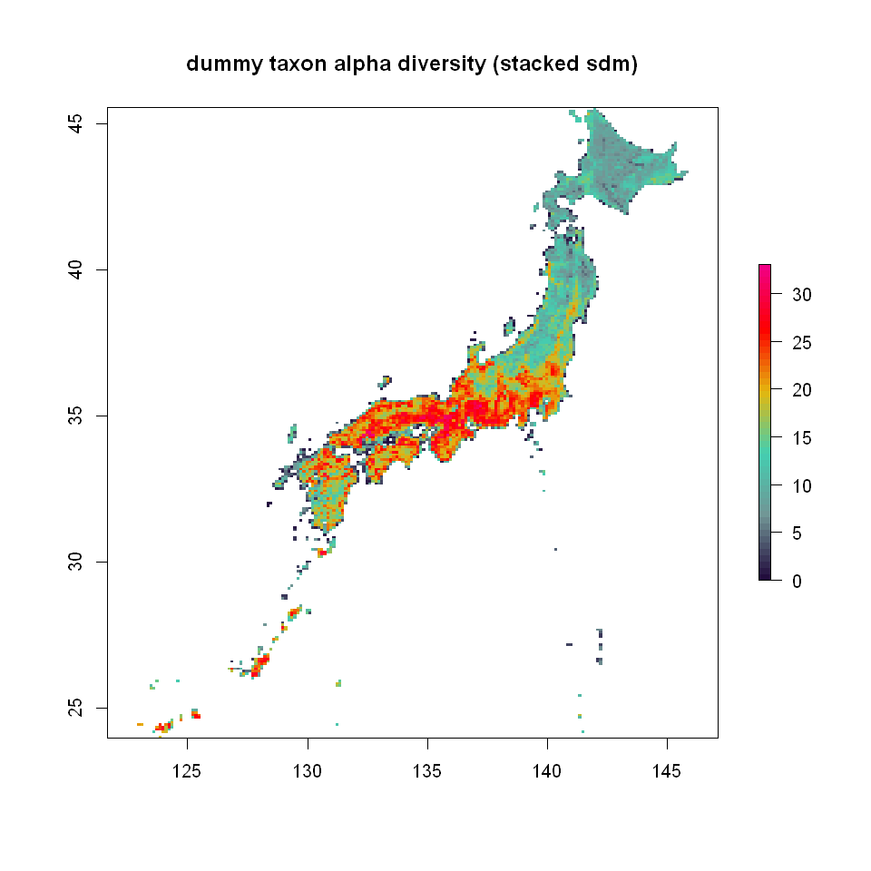

```r
options(repr.plot.width=8, repr.plot.height=8)

plot(tr , col=colorRampPalette(pal)(50))
title(paste("dummy taxon alpha diversity (stacked sdm)"))
```

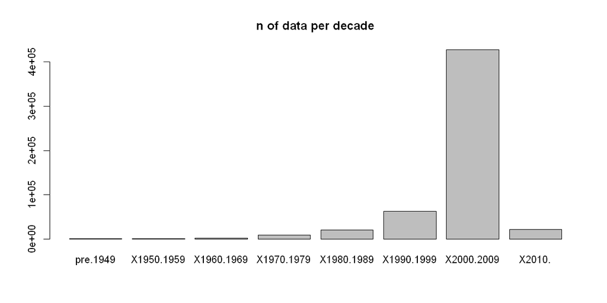

```r
decade_data <- colSums(OCC_DATA[, c("pre.1949", "X1950.1959","X1960.1969", "X1970.1979", "X1980.1989", "X1990.1999", "X2000.2009", "X2010.")], na.rm = T)
options(repr.plot.width=10, repr.plot.height=5)
barplot(decade_data)
title("n of data per decade")
```

```r
td$mesh2 <- as.integer(mesh2get(td$x, td$y))
tdata_t <- merge(tdata_t, td[,c(3,4)], by=c("mesh2"), all=T)

colnames(td) <- c("x", "y", "sr", "mesh2")
td$group <- "dummytaxon"

sr_data <- td
```

```
Warning message:
"Removed 268 rows containing non-finite values (stat_smooth)."
```

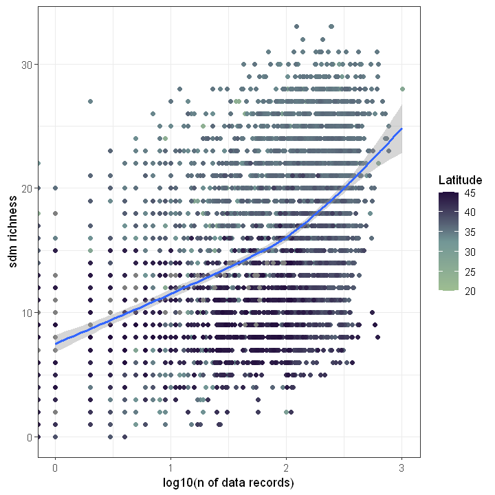

```r
sdm_sr <- td
colnames(sdm_sr) <- c("x", "y", "sdm_richness", "mesh2")
sdm_sr$mesh2 <- mesh2get(sdm_sr$x, sdm_sr$y)
records_ <- merge(records, sdm_sr[, c(3,4)], by="mesh2")

options(repr.plot.width=6, repr.plot.height=6)
ggplot(data=records_ , aes(y=sdm_richness, x=log10(data_n), color=lat)) + geom_point() + stat_smooth()+
scale_color_gradientn(colors = latpal,
                          breaks=seq(20,45, by=5),
                          limits=c(20, 45), name="Latitude")+xlab("log10(n of data records)")+ylab("sdm richness") + theme_bw()
```

↑データレコード数とstacked sdmによる種数推定の関係 ここで残っている相関関係の由来は、ケースバイケースであるので、注意する。

## 種多様性の緯度勾配

```r
jp <- st_read("C:/Users/ikari/Documents/laboratory/data/gis/gadm40_JPN_shp/gadm40_JPN_0.shp")
# 日本の海岸線のシェープファイル
# https://www.naturalearthdata.com/downloads/10m-physical-vectors/10m-coastline/
```

```r
land_area <- aggregate(list("land_a"=tdata_t$land.area), list("y"=as.character(tdata_t$y)), sum)
land_area$y <- as.numeric(land_area$y)

elev <- aggregate(list("elev"=tdata_t$elevation), list("y"=as.character(tdata_t$y)), max)
elev$y <- as.numeric(elev$y)

temp <- aggregate(list("temperature"=tdata_t$bio_1), list("y"=as.character(tdata_t$y)), max)
temp$y <- as.numeric(temp$y)
```

```r
area_stats <- merge(land_area, elev, by="y")
area_stats <- merge(area_stats, temp, by="y")
```

```r
g_sr <- sr_data %>%
ggplot(aes(x=y, y=log10(sr)), color="blue")  + theme_bw() + geom_point(color="lightgray") +
coord_flip(ylim=c(0,1.5))+
theme(legend.position=c(0.5,0.05), text = element_text(size = 18), legend.title=element_blank(), legend.box = "horizontal")+
scale_colour_discrete(guide = guide_legend(direction = "horizontal",
                             label.position="bottom", label.hjust = 0.5, label.vjust = 0.5,
                             label.theme = element_text(angle = 0), nrow=1, label.size=20)) +
geom_text(aes(y=y-100), size=10, label="|") +
xlim(21.3, 48.2) +
geom_area(data=area_stats, aes(x=y, y=land_a/10000000000), color="black", fill="black")+
geom_area(data=area_stats, aes(x=y, y=elev/3000), color="grey", fill="grey", alpha=0.7)+
geom_segment(aes(x=25,xend=45,y=2000000000/10000000000,yend=2000000000/10000000000), color="black", size = 1)+
geom_segment(aes(x=25,xend=45,y=1000/3000,yend=1000/3000), color="grey40", size = 1)+
annotate("text", x=47,   y=2000000000/10000000000, label="sum\nland area\n2000 [km^2]") +
annotate("text", x=24,   y=1000/3000, label="maximum\nmean elevation\n1000 [m]", color="grey40") +
geom_line(data=area_stats, aes(x=y, y=temperature/400), color="red", size = 1) +
geom_segment(aes(x=25,xend=45,y=200/400,yend=200/400), color="thistle4", size = 1)+
annotate("text", x=47,   y=200/400, label="annual mean\ntemperature\n20 [deg]", color="red") +
ylab("log10 (species richness)")+xlab("Latitude")+
stat_smooth(se=T, show.legend=FALSE)




g_map <- ggplot()+
geom_tile(data=sdm_sr, aes(x=x, y=y, fill=sdm_richness	))+
scale_fill_gradientn(colors = pal, na.value = NA, name = "sdm_richness")+
geom_sf(data=jp[1], fill=NA, color=NA)+
coord_sf(xlim = c(122, 146), ylim=c(23, 46))+theme(legend.position=c(0.15,0.8))+
xlab("Longitude")+ylab("Latitude")
```

```
Warning message:
"Removed 19 rows containing non-finite values (stat_smooth)."
```

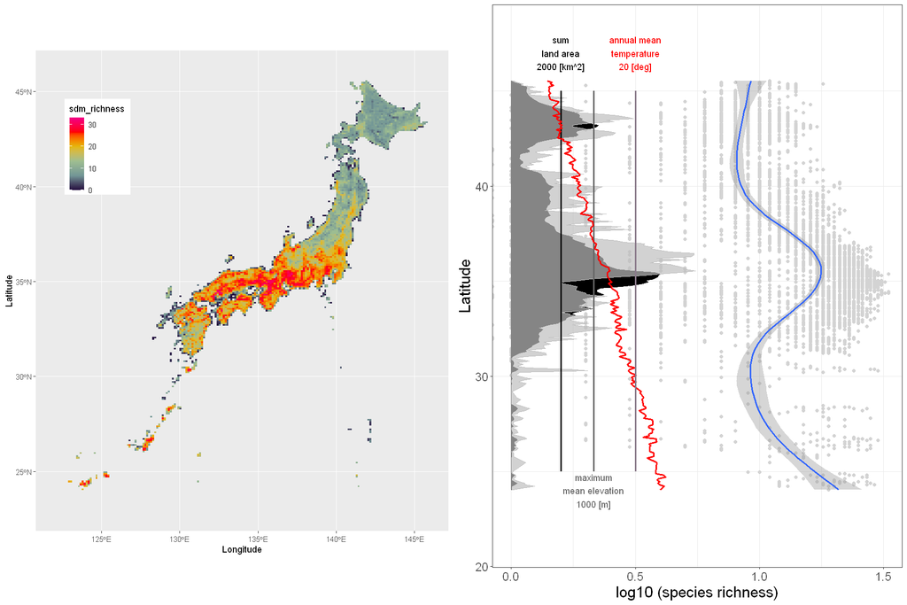

```r
options(repr.plot.width=15, repr.plot.height=10)
gridExtra::grid.arrange(g_map, g_sr,  nrow = 1)
```

## 重回帰分析

```r
regr_df <- tdata_t[, c(-1,-2,-3, -5)]
regr_df$land.area.log <- log10(tdata_t$land.area)

regr_df <- as.data.frame(scale(regr_df ))
head(regr_df)
```

A data.frame: 6 × 22

|  | elevation <dbl> | bio_1 <dbl> | bio_2 <dbl> | bio_3 <dbl> | bio_4 <dbl> | bio_5 <dbl> | bio_6 <dbl> | bio_7 <dbl> | bio_8 <dbl> | bio_9 <dbl> | ... | bio_12 <dbl> | bio_13 <dbl> | bio_14 <dbl> | bio_15 <dbl> | bio_16 <dbl> | bio_17 <dbl> | bio_18 <dbl> | bio_19 <dbl> | dummytaxon <dbl> | land.area.log <dbl> |
| --- | --- | --- | --- | --- | --- | --- | --- | --- | --- | --- | --- | --- | --- | --- | --- | --- | --- | --- | --- | --- | --- |
| 1 | -0.7892809 | 2.736684 | -2.800172 | 0.4713506 | -3.650451 | 1.251908 | 2.948548 | -3.504156 | 1.365727 | 3.161030 | ... | 0.98635178 | -0.22761630 | 1.938040 | -1.959406 | 0.18491202 | 2.070198 | -0.1892556 | 1.4353631 | 0.8576692 | -0.7007703 |
| 2 | -0.8442174 | 2.850721 | -2.648194 | 0.9575733 | -3.743738 | 1.483765 | 3.040073 | -3.491127 | 1.604419 | 2.513176 | ... | 0.08976876 | -0.63762490 | 1.644521 | -1.998015 | -0.45862346 | 1.209402 | -0.4888993 | 0.4667224 | 0.5853785 | -0.9401428 |
| 3 | -0.8306874 | 2.687381 | -2.275350 | 1.5743417 | -3.598125 | 1.329287 | 2.836972 | -3.292824 | 1.589741 | 2.744477 | ... | 0.62836499 | -0.09812043 | 1.862990 | -1.789118 | 0.01222683 | 1.684425 | -0.1815981 | 0.9393124 | -0.2314934 | -3.7500036 |
| 4 | -0.8880531 | 2.768650 | -2.181341 | 1.5901215 | -3.558452 | 1.519144 | 2.856984 | -3.202152 | 1.630887 | 2.647290 | ... | 0.29556264 | -0.34838722 | 1.653020 | -1.797404 | -0.24483778 | 1.372378 | -0.3304567 | 0.5836305 | 0.7215239 | -1.5934609 |
| 5 | -0.5915315 | 2.613035 | -2.195874 | 1.7406187 | -3.567175 | 1.251463 | 2.783657 | -3.264291 | 1.536201 | 2.673680 | ... | 1.04940217 | 0.25938051 | 2.107010 | -1.702147 | 0.37094580 | 2.198369 | 0.2108675 | 1.2664283 | 1.6745411 | -0.2418428 |
| 6 | -0.4103888 | 2.524451 | -2.170765 | 1.7145937 | -3.509854 | 1.146252 | 2.715357 | -3.231217 | 1.470430 | 2.513823 | ... | 1.83311665 | 0.98669159 | 2.265420 | -1.212646 | 1.26976223 | 2.740355 | 0.8492437 | 1.6043167 | 1.2661051 | 0.3784189 |

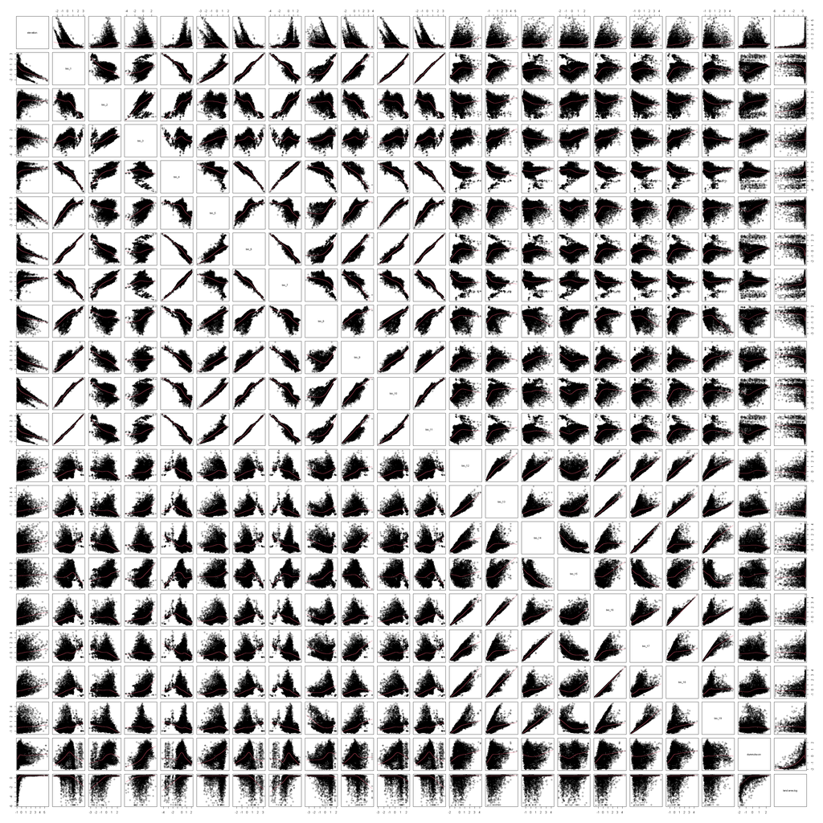

```r
options(repr.plot.width=30, repr.plot.height=30)
pairs(regr_df , panel = panel.smooth)
```

### climate model

```r
clim <- lm(dummytaxon ~ land.area.log  + bio_1 +  bio_3 + bio_12 + bio_15 + I(bio_1^2) +I(bio_1^12) + elevation^2, data=regr_df)
clim_coefs <- as.data.frame(summary(clim)$coefficients)

clim_coefs$val <- c("Intercept", "land area (log)", "annual temp", "temp seasonality", "annual prec", "prec seasonality", "temp^2", "prec^2", "elevation")
colnames(clim_coefs)[2] <- "Std.Error"
clim_coefs
data.frame("adj. R2"=summary(clim)$ adj.r.squared)
vif(clim_best)
```

A data.frame: 9 × 5

|  | Estimate <dbl> | Std.Error <dbl> | t value <dbl> | Pr(>\|t\|) <dbl> | val <chr> |
| --- | --- | --- | --- | --- | --- |
| (Intercept) | 1.080482e-01 | 1.159508e-02 | 9.3184544 | 1.771474e-20 | Intercept |
| land.area.log | 5.715959e-01 | 1.112406e-02 | 51.3837652 | 0.000000e+00 | land area (log) |
| bio_1 | 5.347130e-01 | 1.521722e-02 | 35.1386676 | 2.416884e-240 | annual temp |
| bio_3 | 2.949992e-01 | 1.229281e-02 | 23.9977071 | 3.898741e-120 | temp seasonality |
| bio_12 | -7.964366e-02 | 1.120446e-02 | -7.1082113 | 1.352678e-12 | annual prec |
| bio_15 | -1.048411e-01 | 1.028432e-02 | -10.1942681 | 3.748461e-24 | prec seasonality |
| I(bio_1^2) | -1.089427e-01 | 8.677988e-03 | -12.5539100 | 1.403244e-35 | temp^2 |
| I(bio_1^12) | 2.832962e-07 | 5.401921e-07 | 0.5244361 | 6.000000e-01 | prec^2 |
| elevation | 1.589891e-01 | 1.244585e-02 | 12.7744676 | 9.266933e-37 | elevation |

A data.frame: 1 × 1

| adj..R2 <dbl> |
| --- |
| 0.6558473 |

**land.area.log**

1.69640007131356

**bio_1**

2.20721592037237

**bio_3**

1.98249912002684

**bio_12**

1.3471513845337

**bio_15**

1.44295139907708

**I(bio_1^2)**

1.8672241997876

**I(bio_1^12)**

1.95771822592429

**I(elevation^2)**

1.26967535101845

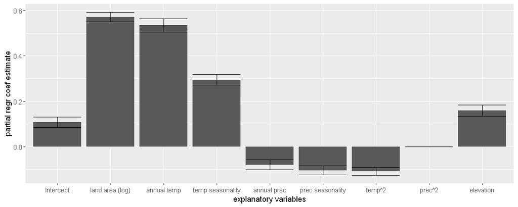

```r
options(repr.plot.width=10, repr.plot.height=4)
clim_coefs %>%
ggplot(aes(x=factor(val, levels=clim_coefs$val), y=Estimate)) + geom_bar(stat="identity")+
geom_errorbar(aes(ymin = Estimate - 1.96*Std.Error, ymax = Estimate + 1.96*Std.Error)) + ylab("partial regr coef estimate")+
xlab("explanatory variables")
```

↑land area の影響が非常に大きいが、これは上の散布図のとおり、陸が狭いメッシュにおいて種数が非常に少なくなるからである。  
グリッド分割の際のこの影響を除いて解析することにより、気候要因等のドライバーの効果を分析しやすくなる。

```r
options(repr.plot.width=7, repr.plot.height=7)
```

### かけがえのなさ

```r
sdm <- readRDS(paste("C:/Users/ikari/Documents/laboratory/projects/202210_seminar/output/dummy_10km_envonly.rds", sep=""))$sdm
```

```r
for(i in 1:length(names(sdm))){
    sdm[[i]][] <- sdm[[i]][] / sum(sdm[[i]][], na.rm=T)
}
irrep <- sdm
irrep_sum <- calc(irrep, sum)
# 総生息面積に対するメッシュ内の生息面積を算出する
```

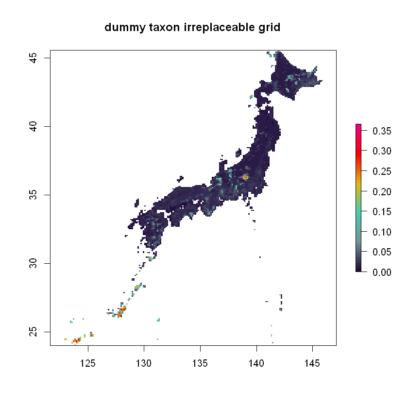

```r
plot(irrep_sum , col=colorRampPalette(pal)(50))
title(paste("dummy taxon irreplaceable grid"))
```

```r
irdf <- as.data.frame(rasterToPoints(irrep_sum))
irdf$mesh2 <- as.integer(mesh2get(irdf$x, irdf$y))

colnames(irdf)[3] <- "irreplaceability"

sdm_sr_irr <- merge(sdm_sr[,c(3,4)], irdf, by="mesh2")
```

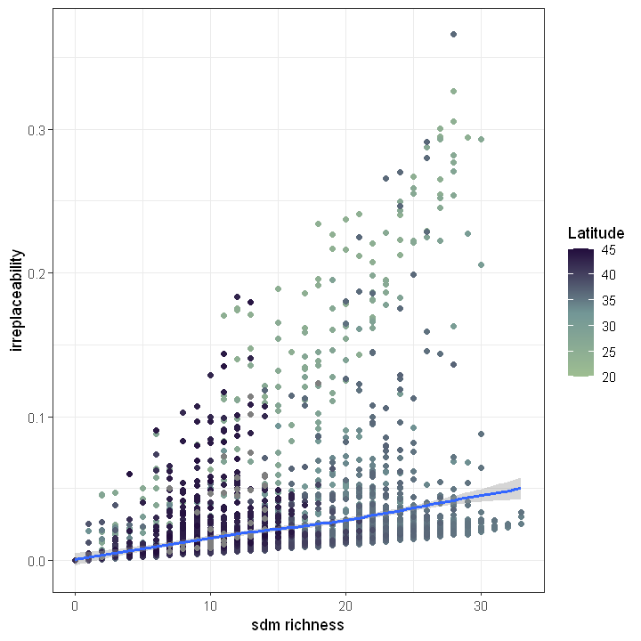

```r
sdm_sr_irr %>%
ggplot(aes(y=irreplaceability, x=sdm_richness, color=y)) + geom_point() + stat_smooth()+
scale_color_gradientn(colors = latpal,
                          breaks=seq(20,45, by=5),
                          limits=c(20, 45), name="Latitude")+xlab("sdm richness")+ylab("irreplaceability") + theme_bw()
```

# coding: shogo ikari 20221022